# La política de la corrupción

Sesión 15: Lo que se llevan

Bogdan G. Popescu

bgpopescu@tec.mx

Tecnológico de Monterrey

# Un curso, una pregunta

## La pregunta que siempre estuvo detrás

Quince sesiones, desde un alto de tránsito en la Ciudad de México hasta una empresa fantasma en el Caribe.

Debajo de todas ellas había una sola pregunta:

> **Casi nadie defiende la corrupción. Entonces, ¿por qué está en todos lados — y qué ha logrado alguna vez que se vaya?**

Hoy no hay material nuevo. Nada más la respuesta — en cuatro preguntas, contada con las diapositivas que más probablemente van a recordar.

## Cuatro preguntas, un semestre

| **Reconocer** | ¿Qué es corrupción, cuando los casos se parecen tanto? |
| --- | --- |
| **Explicar** | ¿Por qué persiste, si nadie la defiende? |
| **Medir** | ¿Cómo sabemos cuánta hay? |
| **Reducir** | ¿Qué funciona de verdad? |

Cuatro preguntas que le pueden hacer a cualquier país, a cualquier gobierno, a cualquier institución — y la primera la van a responder ustedes, ahorita.

Todo lo del semestre cabe en alguno de esos cuatro renglones. Si en diez años recuerdan las cuatro preguntas, el curso cumplió.

Cuatro situaciones reales. Tres votos: *claramente corrupto*, *no es corrupción*, *es complicado*.

|  | Caso | Dónde |  |
| --- | --- | --- | --- |
| **1** | Un alto de tránsito | México | 200 pesos · sin infracción |
| **2** | Despensas antes de la elección | México | despensas · nombres anotados |
| **3** | La puerta giratoria | Estados Unidos | un regulador supervisa un banco; el banco luego lo contrata |
| **4** | La Estafa Maestra | México | universidades · empresas fantasma · 7,670 millones de pesos |

Les pedí que anotaran sus votos y les dije que íbamos a regresar a ellos. Esta es esa diapositiva.

## Caso 1 — ¿Por qué sobrevive el soborno?

México

Supongan que la multa oficial es de 1,000 pesos. En vez de eso, el oficial acepta 200.

- El **conductor se ahorra 800 pesos**.
- El **oficial se gana 200 pesos**.
- El **gobierno pierde 1,000 pesos** de ingresos.

**¿Quién tiene incentivos para denunciar la mordida?**

[figure not shown]

La misma fotografía que vieron el 10 de agosto. Foto: ProtoplasmaKid, Wikimedia Commons, CC BY-SA 4.0.

Hoy pueden explicar y clasificar esta transacción:

- Corrupción **con robo** (S3)
- **Dinero de agilización** (S10)
- Medible con encuestas de **experiencia** (S8)

El conductor se ahorra, el oficial se gana y el público pierde.

## Caso 2 — La misma despensa, cuatro intercambios distintos

México

Un político le da una despensa a una familia antes de la elección.

**¿Qué tiene que hacer la familia a cambio?**

- Cumplir reglas públicas de elegibilidad → **política programática**
- Seguir apoyando al partido → **clientelismo**
- Votar por un candidato en particular → **compra de votos**
- Nada más ir a votar → **compra de participación**

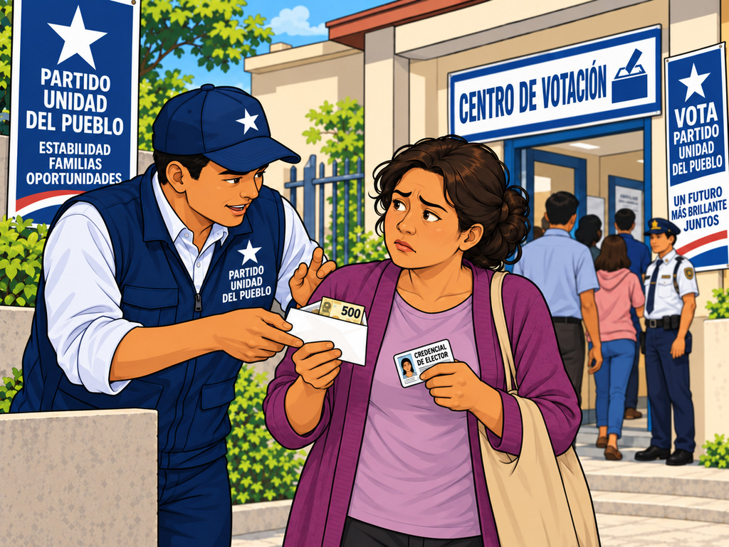

Sesión 9. La misma despensa, cuatro intercambios distintos.

**¿Cuándo se vuelve corrupción?**

Cuando se usan mal recursos públicos para ganar políticamente.

## Dos personas que siguieron todo el semestre

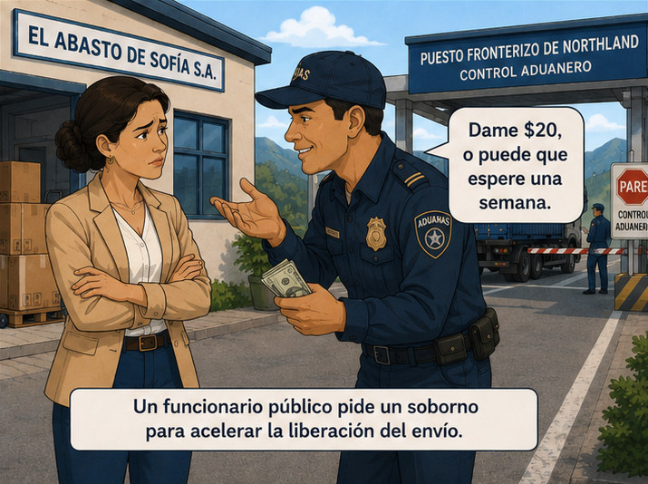

**Sofía**, sesión 3 — solo ese oficial podía liberar la carga, y solo él decidía cuándo.

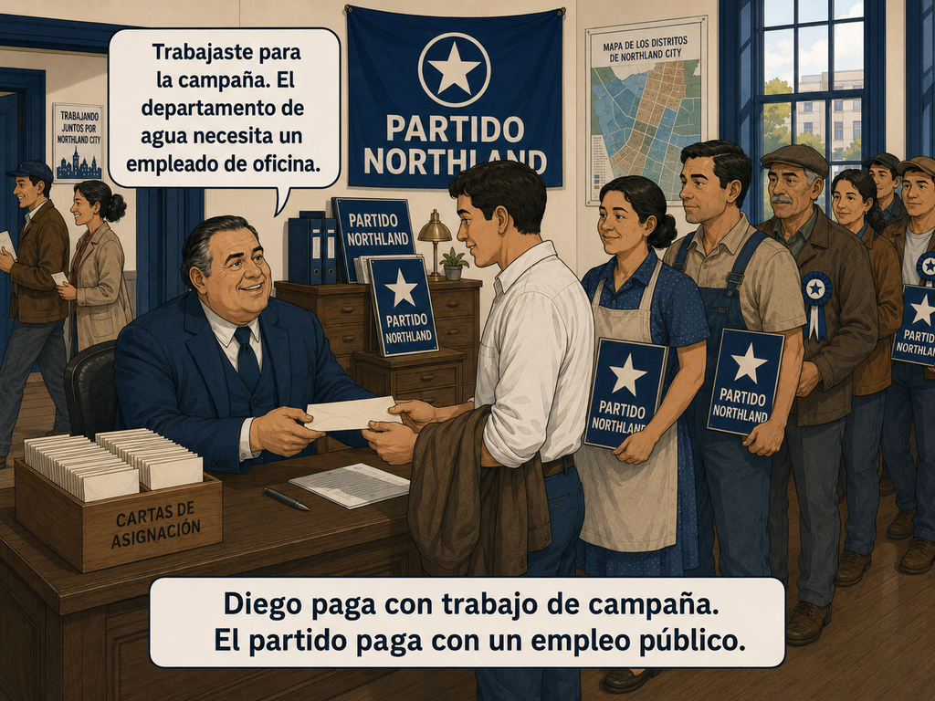

**Diego**, sesión 6 — tres meses de tardes trabajando, y el pago nunca fue dinero.

Ninguno de los dos hizo nada fuera de lo común. Entre los dos cargan el curso completo.

## Explicar — Sofía se quedó parada

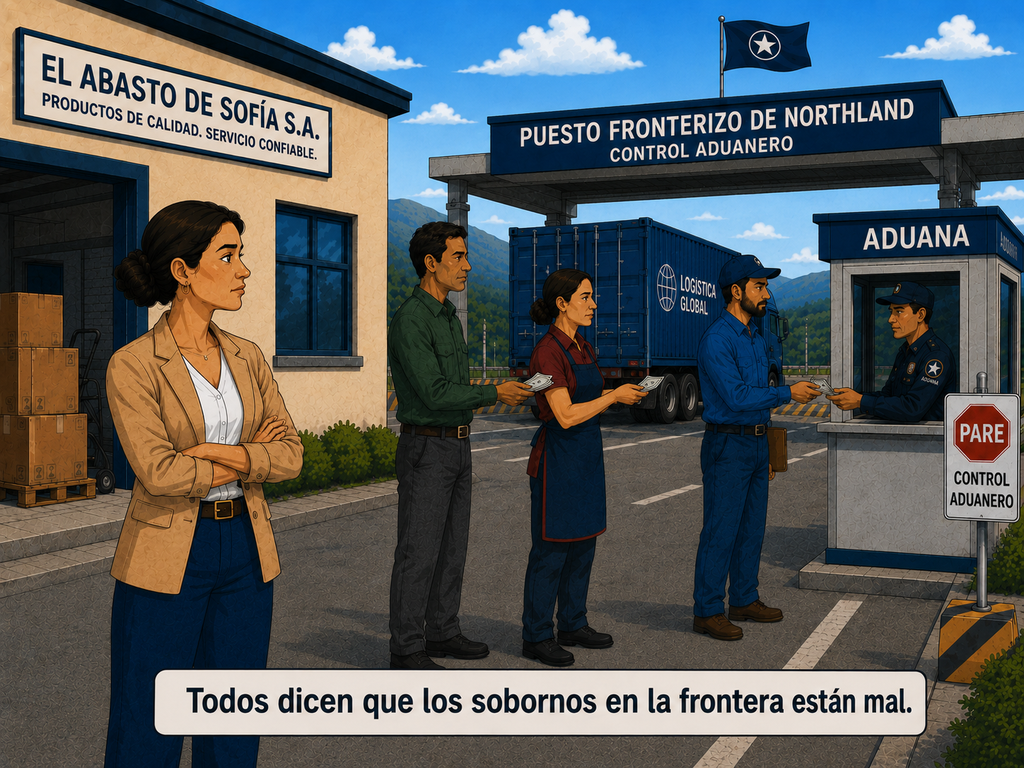

Hasta la gente honesta queda atrapada. Eso es un **equilibrio** — y por eso castigar a los individuos tantas veces no cambia nada.

## Explicar — plata o plomo

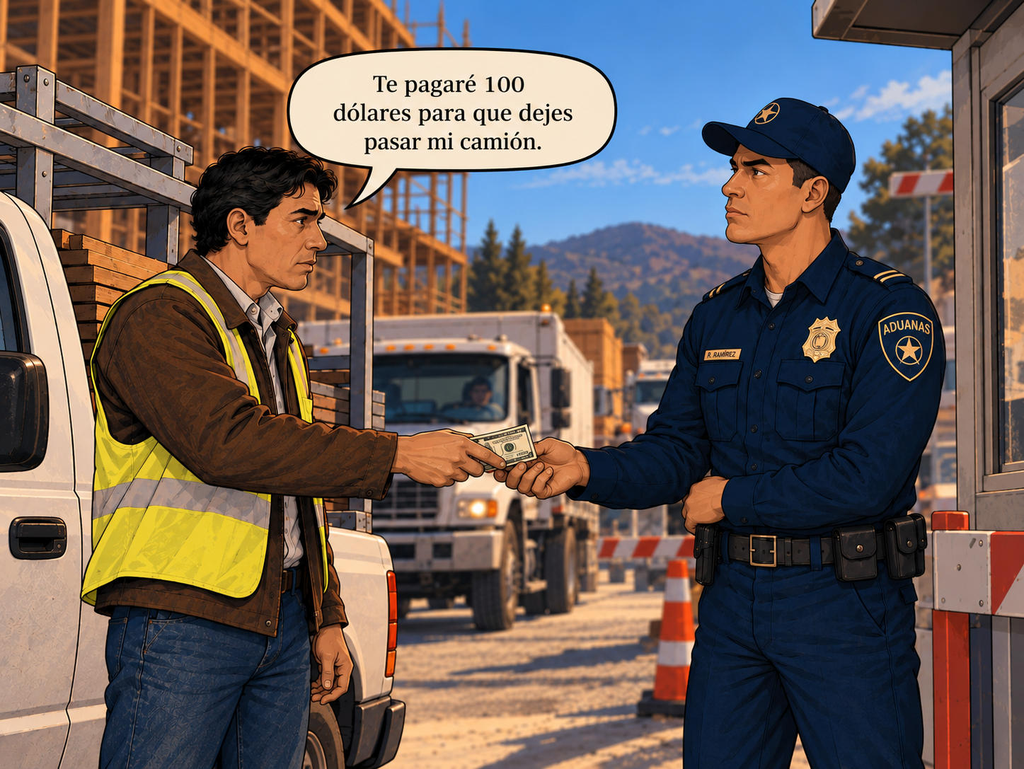

**Diego paga $100.**

[figure not shown]

**El cártel paga $40** — y pone los otros $60 como amenaza.

Los criminales consiguen el mismo favor pagando menos y amenazando más. Los sobornos y las balas son **sustitutos** — así que el dinero que cambia de manos *subestima* qué tan capturada está una oficina.

## Medir — lo que escondía la grava

- Unos ingenieros escarbaron 477 caminos en Java y compararon lo construido con lo facturado: **faltaba 24%** (S8)
- Los precios eran honestos. Las **cantidades** no
- Todos saben cuánto cuesta la grava. Nadie puede ver un montón y decir cuánta llegó

La gente roba lo que es más difícil de verificar.

## Reducir — ¿Combatir al crimen puede aumentar la violencia?

¿Se acuerdan de Diego? La policía detuvo al hombre que lo extorsionaba. Pensó que sus problemas se habían acabado.

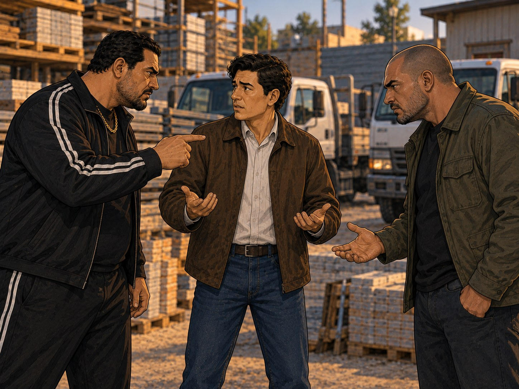

**¿Esto pasó de verdad en México?**

+57

Homicidios adicionales por cada 100,000 habitantes al año en municipios donde el PAN ganó por muy poco, comparados con aquellos donde perdió por muy poco. Dell (2015), sesión 12.

## Reducir — un radar que solo funciona a la hora de la comida

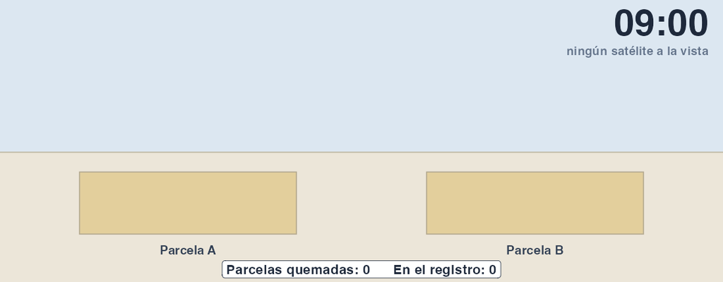

- A los funcionarios de Punjab les pidieron reducir a la mitad los incendios **detectados**. Los satélites pasan entre las 10:30 y las 13:30 (S13)
- Así que las quemas se movieron a la tarde
- Por cada 100 incendios detectados menos, solo unos **22** se evitaron de verdad

**Ley de Goodhart:** cuando una medida se vuelve la meta, la gente mejora la medida.

Dos veces la misma idea: la gente se adapta a las políticas, a veces de maneras que nadie esperaba — y eso es lo que decide si funcionaron.

## Leer las noticias: ¿de verdad bajó la corrupción?

Titular hipotético

### Un nuevo programa anticorrupción reduce la corrupción 30%

| El año pasado | Este año |
| --- | --- |
| **1,000** denuncias | **700** denuncias |

- Tal vez menos funcionarios están pidiendo mordidas.
- Tal vez menos ciudadanos las están denunciando.
- Tal vez la corrupción habría bajado sin el programa.

Menos denuncias no significan necesariamente menos corrupción.

Análisis crítico (S2) · Medición (S8)

## Leer las noticias — ¿la IA atrapó a la corrupción?

Titular hipotético

### La inteligencia artificial identifica 500 empresas corruptas

Un algoritmo revisa contratos de gobierno y marca 500 empresas como sospechosas.

**¿Ya encontramos 500 empresas corruptas?**

- Algunas empresas sospechosas pueden ser inocentes.
- Algunas empresas corruptas pueden escapar a la detección.
- Alguien todavía tiene que revisar la evidencia.

Un algoritmo puede señalar sospechosos. Por sí solo no puede establecer culpabilidad.

Cleptocracia (S11) · Tecnología (S13)

## Hoy leen las mismas noticias de otra manera

| El titular dice… | Ustedes ahora preguntan… |
| --- | --- |
| La corrupción bajó 30%. | ¿Qué fue exactamente lo que se midió? |
| El programa funcionó. | ¿Comparado con qué? |
| La IA atrapó a 500 empresas corruptas. | ¿Qué demuestra realmente la evidencia? |
| Sacamos a los funcionarios corruptos. | ¿Cambiaron sus incentivos? |

Las noticias no cambiaron.

**Lo que cambió es cómo las leen ustedes.**

## Una promesa que les hice el 10 de agosto

El primer día les dije lo que iban a poder hacer al terminar este curso.

| Lo que les prometí | Lo que pueden hacer hoy |
| --- | --- |
| Distinguir soborno, fraude, clientelismo, patronazgo y captura del Estado | **Reconocer la corrupción en sus muchas formas**, incluso cuando viene disfrazada o es legal. |
| Explicar por qué la corrupción persiste en algunos países | **Explicar por qué hasta la gente honesta participa** en sistemas corruptos. |
| Sopesar lo que dice la evidencia sobre cuánto cuesta la corrupción | **Evaluar la evidencia** detrás de las afirmaciones sobre corrupción, pobreza y crecimiento. |
| Comparar cómo algunos países redujeron la corrupción, y por qué | **Explicar por qué unas reformas funcionan y otras salen contraproducentes.** |
| Leer un estudio y decir qué estableció realmente | **Leer investigación por su cuenta**, detectar debilidades y llegar a sus propias conclusiones. |

En agosto les pregunté qué opinaban.

Hoy les puedo preguntar qué piensan, por qué lo piensan y qué evidencia lo sostiene.

## Más que un curso sobre corrupción

- **Leer por su cuenta** — entender material difícil sin depender de la explicación de alguien más.
- **Evaluar evidencia** — reconocer cuándo una estadística no sostiene la conclusión.
- **Comunicar con claridad** — explicar un argumento complicado en diez minutos.
- **Defender un argumento** — responder preguntas difíciles sin guion.

Puede que nunca trabajen en temas de corrupción.

Pero estas habilidades les van a seguir sirviendo.

## Deberían estar orgullosos de lo que lograron

16

**Lecturas obligatorias**

Investigación académica original, más 28 lecturas recomendadas disponibles.

29

**Presentaciones**

Explicar y defender argumentos complejos frente al grupo.

~20

**Preguntas críticas cada uno**

Formar su propio criterio.

Su lista de lecturas incluyó artículos de algunas de las revistas académicas más importantes del mundo:

- *Quarterly Journal of Economics*
- *American Political Science Review*
- *American Economic Review*
- *Journal of Political Economy*

El tipo de investigación que se lee en los mejores programas de posgrado del mundo.

Ustedes no nada más leyeron esa investigación. Aprendieron a cuestionarla.

**Eso es un logro. Siéntanse orgullosos.**

# Por qué enseñé como enseñé

## Por qué les pedí tanto

Cada tarea exigente tenía un propósito.

| Lo que les pedí hacer | Lo que quería que aprendieran |
| --- | --- |
| Leer artículos académicos difíciles | **Entender información compleja** por su cuenta |
| Escribir preguntas antes de clase | **Pensar por ustedes mismos** antes de oír la opinión de alguien más |
| Presentar en diez minutos | **Explicar ideas complicadas** en palabras simples |
| Responder preguntas difíciles | **Pensar con claridad**, aunque los agarren en curva |

Son habilidades que van a necesitar en entrevistas de trabajo, en juntas, en otras materias y en decisiones importantes de su vida.

Les exigí mucho porque creía que eran capaces de mucho.

## Por qué fui exigente

| Lo que les pedí | Por qué me importaba |
| --- | --- |
| Guardar el celular | Quería que estuvieran **presentes mentalmente**, no nada más físicamente. |
| Llegar a tiempo y quedarse | Quería que todos fueran **parte de la discusión**. |
| Responder preguntas, aunque no levantaran la mano | Quería que todos **practicaran pensar y expresar sus ideas**, no solo los más seguros. |

No quería que fueran espectadores de su propia educación.

Quería que cada uno de ustedes fuera un participante activo.

## Gracias

Quince sesiones. Cuarenta y cuatro lecturas. Veintinueve presentaciones. Y un salón que respondía y discutía — que es justo la parte que no se puede poner en un programa de curso.

Gracias. Fue un buen curso para dar.

bgpopescu@tec.mx

bgpopescu.net/teaching/corruption

## Evaluación docente

forms.gle/3VzPTovn8FxbWSUG9